# DART-seq_m6A_dataset

```r
library(VeloRM)
```

## DART_seq velocity pipeline

### data download

https://www.ncbi.nlm.nih.gov/geo/query/acc.cgi?acc=GSE125780 ### alignment

```bash
# Base directories
input_base="/gpfs/work/bio/haozhewang17/data/GSE125780/SRR"
output_base="/gpfs/work/bio/haozhewang17/data/GSE125780/SRR"

srr = SRR9940470 #SRR9940471 SRR9940472 SRR9940474 SRR9940475 SRR9940476

echo "Processing sample: $srr"
# Input FASTQ file (assuming it's in ${input_base}/${srr}/${srr}.fastq)
# Run trim_galore (single-end mode)
trim_galore \
   --output_dir "${output_base}/${srr}" \
   --basename "${srr}" \
   "${input_base}/${srr}/${srr}.fastq"


srr = SRR9940470 #SRR9940471 SRR9940472 SRR9940474 SRR9940475 SRR9940476

echo "Processing sample: $srr"
STAR --runThreadN 1 \
--outSAMtype BAM Unsorted \
--readFilesIn "${input_base}/${srr}/${srr}_trimmed.fq" \
--genomeDir /gpfs/work/bio/haozhewang17/data/VeloRM_2/hg38/star_indx \
--sjdbGTFfile /gpfs/work/bio/haozhewang17/data/VeloRM_2/hg38/Homo_sapiens.GRCh38.109.gtf \
--outFileNamePrefix "${output_base}/${srr}/${srr}" \
--outSAMattributes All \
--outSAMunmapped Within \
--sjdbOverhang 150 > "${output_base}/${srr}/${srr}.log"


srr = SRR9940470 #SRR9940471 SRR9940472 SRR9940474 SRR9940475 SRR9940476

echo "Processing sample: $srr"
samtools sort -@ 1 -o "${output_base}/${srr}/${srr}_sorted.bam" "${output_base}/${srr}/${srr}Aligned.out.bam"

echo "Processing sample: $srr"
samtools view -h -b -q 30 \
"${input_base}/${srr}/${srr}_sorted.bam" \
    -o "${input_base}/${srr}/${srr}_above.mapQ30.bam"
```

### divide bam

```bash
###########################################################
# File prepare
###########################################################

## get exon-no-ambiguity bed by substract (exon.bed - intron.bed = exon-na.bed)
bedtools subtract -a UCSC_Exons.bed -b UCSC_Introns.bed > exon-na.bed

## get intron-no-ambituity bed by subtract (inton.bed - exon.bed = inron-na.bed)
bedtools subtract -a UCSC_Introns.bed -b UCSC_Exons.bed > inron-na.bed

###########################################################
### divide bam into spliced bam and unspliced bam
###########################################################


srr_list=("SRR9940470") # SRR9940471 SRR9940472 SRR9940474 SRR9940475 SRR9940476


# Base directories
input_base="/gpfs/work/bio/haozhewang17/data/GSE125780/SRR"
output_base="/gpfs/work/bio/haozhewang17/data/GSE125780/SRR"




#### mRNA.bam
for srr in "${srr_list[@]}"; do
    echo "Processing sample: $srr"
    bedtools intersect -a "${input_base}/${srr}/${srr}_above.mapQ30.bam"\
    -b /gpfs/work/bio/haozhewang17/data/VeloRM_2/hg38_bed/UCSC_Introns.bed\
    -v -wa -split > "${input_base}/${srr}/${srr}_mRNA_temp.bam"
done

for srr in "${srr_list[@]}"; do
    echo "Processing sample: $srr"
    bedtools intersect -a "${input_base}/${srr}/${srr}_mRNA_temp.bam"\
    -b /gpfs/work/bio/haozhewang17/data/VeloRM_2/hg38_bed/UCSC_Exons.bed\
    -wa -split > "${input_base}/${srr}/${srr}_mRNA.bam"
    samtools index "${input_base}/${srr}/${srr}_mRNA.bam"
done

 #### mRNA_spliced.bam

for srr in "${srr_list[@]}"; do
    echo "Processing sample: $srr"
    samtools view -h "${input_base}/${srr}/${srr}_mRNA.bam"\
    | awk '$0 ~ /^@/ || $6 ~ /N/' | samtools view -b >\
    "${input_base}/${srr}/${srr}_mRNA_spliced.bam"
    samtools index "${input_base}/${srr}/${srr}_mRNA_spliced.bam"
done


  #### pre-mRNA.bam

for srr in "${srr_list[@]}"; do
    echo "Processing sample: $srr"
    bedtools intersect -a "${input_base}/${srr}/${srr}_above.mapQ30.bam"\
    -b /gpfs/work/bio/haozhewang17/data/VeloRM_2/hg38_bed/intron-na.bed\
    -wa -split > "${input_base}/${srr}/${srr}_pre-mRNA.bam"
    samtools index "${input_base}/${srr}/${srr}_pre-mRNA.bam"
done


  #### isoform-a.bam

for srr in "${srr_list[@]}"; do
    echo "Processing sample: $srr"
    bedtools intersect -a "${input_base}/${srr}/${srr}_above.mapQ30.bam"\
    -b /gpfs/work/bio/haozhewang17/data/VeloRM_2/hg38_bed/UCSC_Introns.bed\
    -wa -split > "${input_base}/${srr}/${srr}_maybe_pre_mRNA.bam"
done

for srr in "${srr_list[@]}"; do
    echo "Processing sample: $srr"
    bedtools intersect -a "${input_base}/${srr}/${srr}_maybe_pre_mRNA.bam"\
    -b /gpfs/work/bio/haozhewang17/data/VeloRM_2/hg38_bed/intron-na.bed\
    -v -wa -split > "${input_base}/${srr}/${srr}_isoform-a.bam"
    samtools index "${input_base}/${srr}/${srr}_isoform-a.bam"
done


#### we can also do further to clean the splicing reads missing classify to ambiguous and pre-mRNA, and merge the splicing reads to mRNA.


#  for srr in "${srr_list[@]}"; do
#    echo "Processing sample: $srr"
#    samtools view -h "${input_base}/${srr}/${srr}_pre-mRNA.bam"\
#    | awk '$0 ~ /^@/ || $6 ~ /N/' | samtools view -b >\
#    "${input_base}/${srr}/${srr}_pre-mRNA_spliced.bam"
#    samtools index "${input_base}/${srr}/${srr}_pre-mRNA_spliced.bam"
#  done

#  for srr in "${srr_list[@]}"; do
#    echo "Processing sample: $srr"
#    samtools view -h "${input_base}/${srr}/${srr}_isoform-a.bam"\
#    | awk '$0 ~ /^@/ || $6 ~ /N/' | samtools view -b >\
#    "${input_base}/${srr}/${srr}_isoform-a_spliced.bam"
#    samtools index "${input_base}/${srr}/${srr}_isoform-a_spliced.bam"
#  done


#  for srr in "${srr_list[@]}"; do
#    echo "Processing sample: $srr"
#    bedtools subtract -a "${input_base}/${srr}/${srr}_pre-mRNA.bam"\
#     -b "${input_base}/${srr}/${srr}_pre-mRNA_spliced.bam"\
#      > "${input_base}/${srr}/${srr}_pre-mRNA_clean.bam"
#  done

#  for srr in "${srr_list[@]}"; do
#    echo "Processing sample: $srr"
#    bedtools subtract -a "${input_base}/${srr}/${srr}_isoform-a.bam"\
#     -b "${input_base}/${srr}/${srr}_isoform-a_spliced.bam"\
#      > "${input_base}/${srr}/${srr}_isoform-a_clean.bam"
#  done

#  for srr in "${srr_list[@]}"; do
#    echo "Processing sample: $srr"
#    samtools merge "${input_base}/${srr}/${srr}_mRNA_spliced_combine.bam"\
#     "${input_base}/${srr}/${srr}_pre-mRNA_spliced.bam"\
#     "${input_base}/${srr}/${srr}_isoform-a_spliced.bam"\
#     "${input_base}/${srr}/${srr}_mRNA_spliced.bam"
#  done
```

### variance calling

```bash
#### call variance


srr_list=("SRR9940470") # SRR9940471 SRR9940472 SRR9940474 SRR9940475 SRR9940476


# Base directories
input_base="/gpfs/work/bio/haozhewang17/data/GSE125780/SRR"
output_base="/gpfs/work/bio/haozhewang17/data/GSE125780/SRR"


for srr in "${srr_list[@]}"; do
    echo "Processing sample: $srr"
    bcftools mpileup -f /gpfs/work/bio/haozhewang17/data/VeloRM_2/hg38/Homo_sapiens.GRCh38.dna.primary_assembly.fa\
    "${input_base}/${srr}/${srr}_sorted.bam" | \
    bcftools call -mv -Oz -o "${input_base}/${srr}/${srr}_calls.vcf"
done
```

### find relevant mutation

```r
# Extract SRR sample folder names into a character vector (skip the header line)
srr_info <- list.dirs("/gpfs/work/bio/haozhewang17/data/GSE125780/SRR/", recursive = FALSE, full.names = FALSE)
srr_info <- srr_info[grepl("SRR", srr_info)]  # Keep only directories containing "SRR"

# Load required packages
library(GenomicRanges)
library(vcfR)
library(Biostrings)
library(TxDb.Hsapiens.UCSC.hg38.knownGene)
library(BSgenome.Hsapiens.UCSC.hg38)

# Loop over each SRR sample
for (srr in srr_info) {
  # Load VCF file
  data <- read.vcfR(paste0("/gpfs/work/bio/haozhewang17/data/GSE125780/SRR/", srr, "/", srr, "_calls.vcf"))
  data2 <- as.data.frame(data@fix)

  # Keep entries with valid nucleotide bases
  data2 <- data2[data2$REF %in% c('A', 'C', 'G', 'T') & data2$ALT %in% c('A', 'C', 'G', 'T'), ]

  if (nrow(data2) == 0) {
    # If no valid SNPs, save empty object
    saveRDS(NULL, paste0("/gpfs/work/bio/haozhewang17/data/GSE125780/SRR/", srr, "/", srr, "SNP.rds"))
  } else {
    # Create GRanges object for SNPs
    gr <- GRanges(seqnames = paste0("chr", data2$CHROM),
                  ranges = IRanges(start = as.numeric(data2$POS), width = 1),
                  strand = '+',
                  ref = data2$REF,
                  alt = data2$ALT,
                  quality = as.numeric(data2$QUAL),
                  info = data2$INFO)

    # Keep only standard chromosomes
    gr <- keepStandardChromosomes(gr, pruning.mode = "coarse")

    # Validate reference bases with genome
    ref <- as.character(DNAStringSet(Views(Hsapiens, gr)))
    gr <- gr[gr$ref == ref]

    saveRDS(gr, paste0("/gpfs/work/bio/haozhewang17/data/GSE125780/SRR/", srr, "/", srr, "SNP.rds"))

    # Load transcript annotation
    transcript <- transcripts(TxDb.Hsapiens.UCSC.hg38.knownGene)
    transcript_plus <- transcript[strand(transcript) == "+"]
    transcript_minus <- transcript[strand(transcript) == "-"]

    # Filter A>G mutations on the + strand
    gr_plus <- gr
    olp <- findOverlaps(gr_plus, transcript_plus)
    gr_plus <- gr_plus[queryHits(olp)]
    gr_plus$transcript_overlapped <- transcript_plus[subjectHits(olp)]$tx_name
    if (length(gr_plus) > 0) {
      gr_plus$transcript_strand <- '+'
      gr_plus <- unique(gr_plus)

      gr_plus$seq <- as.character(DNAStringSet(Views(Hsapiens,gr_plus+1)))
      indx <- which(gr_plus$seq == 'ACA'|gr_plus$seq == 'ACG'|gr_plus$seq == 'ACC'|gr_plus$seq == 'ACT')
      gr_plus <- gr_plus[indx]
      indx <- which(gr_plus$alt == 'T')
      gr_plus <- gr_plus[indx]
    } else {
      gr_plus <- NULL
    }

    # Filter T>C mutations on the - strand (reverse-complement)
    gr_minus <- gr
    strand(gr_minus) <- '-'
    olp <- findOverlaps(gr_minus, transcript_minus)
    gr_minus <- gr_minus[queryHits(olp)]
    gr_minus$transcript_overlapped <- transcript_minus[subjectHits(olp)]$tx_name
    if (length(gr_minus) > 0) {
      gr_minus$transcript_strand <- '-'
      gr_minus <- unique(gr_minus)

      strand(gr_minus) <- '+'
      gr_minus$seq <- as.character(DNAStringSet(Views(Hsapiens,gr_minus+1)))
      indx <- which(gr_minus$seq == 'AGT'|gr_minus$seq == 'CGT'|gr_minus$seq == 'GGT'|gr_minus$seq == 'TGT')
      gr_minus <- gr_minus[indx]
      indx <- which(gr_minus$alt == 'A')
      gr_minus <- gr_minus[indx]
    } else {
      gr_minus <- NULL
    }

    # Combine both strand results and save
    gr_filtered <- c(gr_plus, gr_minus)
    saveRDS(gr_filtered, paste0("/gpfs/work/bio/haozhewang17/data/GSE125780/SRR/", srr, "/", srr, "SNP_filtered.rds"))
  }

  print(paste0("Finished processing ", srr))
}

# Combine all filtered SNPs across samples
gr_all <- GRanges()
for (srr in srr_info) {
  gr <- readRDS(paste0("/gpfs/work/bio/haozhewang17/data/GSE125780/SRR/", srr, "/", srr, "SNP_filtered.rds"))
  if (!is.null(gr)) {
    gr_all <- c(gr_all, gr)
  }
}
gr_all <- unique(gr_all)

# Save combined SNP results
saveRDS(gr_all, "/gpfs/work/bio/haozhewang17/data/GSE125780/SRR/SNP_all.rds")
```

### base counting

```r
# Extract SRR sample folder names into a character vector (skip the header line)
srr_info <- list.dirs("/gpfs/work/bio/haozhewang17/data/GSE125780/SRR", recursive = FALSE, full.names = FALSE)
srr_info <- srr_info[grepl("SRR", srr_info)]  # Keep only directories containing "SRR"

library(GenomicRanges)
library(Biostrings)
library(GenomicAlignments)
library(Rsamtools)


gr_all<- readRDS('/gpfs/work/bio/haozhewang17/data/GSE125780/SRR/SNP_all.rds')


gr_all <-gr_all[,-c(1:5)]

seqlevels(gr_all) <- sub("^chr", "", seqlevels(gr_all))

## base counting
j <- 0
for (srr in srr_info) {

  time_0 <- Sys.time()
  j <- j+1
  name <- srr
  path <- paste0("/gpfs/work/bio/haozhewang17/data/GSE125780/SRR/",srr,"/")

  ################################## mRNA_spliced.bam
  ##################################
  bamfilePath <- paste0(path,srr,'_mRNA_spliced.bam')
  flag <- scanBamFlag(isNotPassingQualityControls=FALSE,
                      isDuplicate=FALSE)
  param <- ScanBamParam(flag=flag, what=c("seq","qual"),which=gr_all)
  alns <- readGAlignments(bamfilePath, param=param)
  alns <- keepStandardChromosomes(alns,pruning.mode = "coarse")
  qseq <- mcols(alns)$seq
  qual <- mcols(alns)$qual
  seqlevels(alns) <- seqlevels(gr_all)

  nucl_piles <- pileLettersAt(qseq, seqnames(alns), start(alns),
                              cigar(alns), gr_all)
  frequency <- alphabetFrequency(nucl_piles, baseOnly=TRUE)

  saveRDS(nucl_piles,paste0(bamfilePath,'_nucl_piles_all.rds'))
  saveRDS(frequency,paste0(bamfilePath,'_frequency_all.rds'))
  rm(param,alns,qseq,qual,nucl_piles,frequency,flag)

  time_1 <- Sys.time()
  ################################## pre-mRNA.bam
  ##################################
  bamfilePath <- paste0(path,srr,'_pre-mRNA.bam')
  flag <- scanBamFlag(isNotPassingQualityControls=FALSE,
                      isDuplicate=FALSE)
  param <- ScanBamParam(flag=flag, what=c("seq","qual"),which=gr_all)
  alns <- readGAlignments(bamfilePath, param=param)
  alns <- keepStandardChromosomes(alns,pruning.mode = "coarse")
  qseq <- mcols(alns)$seq
  qual <- mcols(alns)$qual
  seqlevels(alns) <- seqlevels(gr_all)

  nucl_piles <- pileLettersAt(qseq, seqnames(alns), start(alns),
                              cigar(alns), gr_all)
  frequency <- alphabetFrequency(nucl_piles, baseOnly=TRUE)

  saveRDS(nucl_piles,paste0(bamfilePath,'_nucl_piles_all.rds'))
  saveRDS(frequency,paste0(bamfilePath,'_frequency_all.rds'))
  rm(param,alns,qseq,qual,nucl_piles,frequency,flag)

  time_2 <- Sys.time()
  ################################## isoform.bam
  ##################################
  bamfilePath <- paste0(path,srr,'_isoform-a.bam')
  flag <- scanBamFlag(isNotPassingQualityControls=FALSE,
                      isDuplicate=FALSE)
  param <- ScanBamParam(flag=flag, what=c("seq","qual"),which=gr_all)
  alns <- readGAlignments(bamfilePath, param=param)
  alns <- keepStandardChromosomes(alns,pruning.mode = "coarse")
  qseq <- mcols(alns)$seq
  qual <- mcols(alns)$qual
  seqlevels(alns) <- seqlevels(gr_all)

  nucl_piles <- pileLettersAt(qseq, seqnames(alns), start(alns),
                              cigar(alns), gr_all)
  frequency <- alphabetFrequency(nucl_piles, baseOnly=TRUE)

  saveRDS(nucl_piles,paste0(bamfilePath,'_nucl_piles_all.rds'))
  saveRDS(frequency,paste0(bamfilePath,'_frequency_all.rds'))
  rm(param,alns,qseq,qual,nucl_piles,frequency,flag)
    time_3 <- Sys.time()

  print(j)
  print(paste0("spliced mRNA runing time", time_1-time_0))
  print(paste0("pre-mRNA runing time", time_2-time_1))
    print(paste0("isoform-mRNA runing time", time_3-time_2))
}


#combine
# Extract SRR sample folder names into a character vector (skip the header line)
srr_info <- list.dirs("/gpfs/work/bio/haozhewang17/data/GSE125780/SRR", recursive = FALSE, full.names = FALSE)
srr_info <- srr_info[grepl("SRR", srr_info)]  # Keep only directories containing "SRR"



# Initialize the spliced_list
spliced_list <- list()
j = 1
for (srr in srr_info) {
  name <- srr
  path <- paste0('/gpfs/work/bio/haozhewang17/data/GSE125780/SRR/', srr,"/")
  spliced_list[[j]] <- readRDS(paste0(path, srr, "_mRNA_spliced.bam_frequency_all.rds"))
  j = j + 1
}

# Name the elements of spliced_list
names(spliced_list) <- srr_info
saveRDS(spliced_list, "/gpfs/work/bio/haozhewang17/data/GSE125780/SRR/spliced_m6A.rds")

# Initialize the pre_list
pre_list <- list()
j = 1
for (srr in srr_info) {
  name <- srr
  path <- paste0('/gpfs/work/bio/haozhewang17/data/GSE125780/SRR/', srr,"/")
  pre_list[[j]] <- readRDS(paste0(path, srr, "_pre-mRNA.bam_frequency_all.rds"))
  j = j + 1
}

# Name the elements of isoform_list
names(pre_list) <- srr_info
saveRDS(pre_list, "/gpfs/work/bio/haozhewang17/data/GSE125780/SRR/pre_m6A.rds")


# Initialize the isoform_list
isoform_list <- list()
j = 1
for (srr in srr_info) {
  name <- srr
  path <- paste0('/gpfs/work/bio/haozhewang17/data/GSE125780/SRR/', srr,"/")
  isoform_list[[j]] <- readRDS(paste0(path, srr, "_isoform-a.bam_frequency_all.rds"))
  j = j + 1
}

# Name the elements of pre_list
names(isoform_list) <- srr_info
saveRDS(isoform_list, "/gpfs/work/bio/haozhewang17/data/GSE125780/SRR/isoform_m6A.rds")
```

### summary the count

```bash
module load samtools/1.16.1-gcc-8.5.0-teyetiz



root_dir="/gpfs/work/bio/haozhewang17/data/GSE125780/SRR"


output_file="bam_read_counts.csv"



echo "Folder,isoform-a.bam,mRNA_spliced.bam,pre-mRNA.bam" > "$output_file"


for folder in "$root_dir"/SRR*; do
    if [ -d "$folder" ]; then
        folder_name=$(basename "$folder")
        echo "Processing folder: $folder_name"


        isoform_a_count="Not found"
        mrna_spliced_count="Not found"
        pre_mrna_count="Not found"

        #isoform-a.bam
        isoform_a_file=$(find "$folder" -name "*_isoform-a.bam" | head -n 1)
        if [ -n "$isoform_a_file" ] && [ -f "$isoform_a_file" ]; then
            isoform_a_count=$(samtools view -c "$isoform_a_file")
        fi

        #mRNA_spliced.bam
        mrna_spliced_file=$(find "$folder" -name "*_mRNA_spliced.bam" | head -n 1)
        if [ -n "$mrna_spliced_file" ] && [ -f "$mrna_spliced_file" ]; then
            mrna_spliced_count=$(samtools view -c "$mrna_spliced_file")
        fi

        #pre-mRNA.bam
        pre_mrna_file=$(find "$folder" -name "*_pre-mRNA.bam" | head -n 1)
        if [ -n "$pre_mrna_file" ] && [ -f "$pre_mrna_file" ]; then
            pre_mrna_count=$(samtools view -c "$pre_mrna_file")
        fi

        #
        echo "$folder_name,$isoform_a_count,$mrna_spliced_count,$pre_mrna_count" >> "$output_file"
    fi
done

echo "Processing complete. Results saved to $output_file"
```

We will get the following data in VeloRM_data/DART-seq/origin

Processed Data

The following datasets are generated after preprocessing:

SNP_all.rds

bam_read_counts.csv

Frequency Data

Frequency matrices used for downstream analysis:

isoform_m6A.rds

pre_m6A.rds

spliced_m6A.rds ## pre-process ### extract the modification read counts and un-modification read counts

```r
##  pre



frequency_all <- readRDS("/gpfs/work/bio/haozhewang17/data/VeloRM_data/DART-seq/origin/pre_m6A.rds")


testSNP_all <- readRDS("/gpfs/work/bio/haozhewang17/data/VeloRM_data/DART-seq/origin/SNP_all.rds")


head(frequency_all[[1]])
testSNP_all

frequency_all <- frequency_all[1:3]

library(dplyr)
# get the number of cell number of sites

num_cell <- length(frequency_all)
num_sites <- length(testSNP_all)

# get the index of the + - STAND

strand <- testSNP_all$transcript_strand
strand_plus <- which(strand=="+")
strand_minus <- which(strand=="-")

error_rate_list <- list()

error_reads_list <- list()
methylation_rate <- list()

site_length_nomatch <-  which(lapply(frequency_all, function(x) dim(x)[1])!=length(testSNP_all))


for (i in 1:num_cell){

  # change to data frame and add strand column

  frequency_all[[i]] <-  data.frame(frequency_all[[i]])

  # get methylated reads

  methylated_reads <- rep(0, num_sites)
  methylated_reads[strand_plus] <- frequency_all[[i]][strand_plus,4]
  methylated_reads[strand_minus] <-frequency_all[[i]][strand_minus,1]

  # get unmethylated reads

  unmethylated_reads <- rep(0, num_sites)
  unmethylated_reads[strand_plus] <- frequency_all[[i]][strand_plus,2]
  unmethylated_reads[strand_minus] <- frequency_all[[i]][strand_minus,3]



  # get error reads

  error_reads <- rep(0, num_sites)
  error_reads[strand_plus] <- frequency_all[[i]][strand_plus,1]+frequency_all[[i]][strand_plus,3]+
    frequency_all[[i]][strand_plus,5]
  error_reads[strand_minus] <- frequency_all[[i]][strand_minus,2]+frequency_all[[i]][strand_minus,4]+
    frequency_all[[i]][strand_minus,5]



  frequency_all[[i]] <- frequency_all[[i]] %>%
    mutate(methylated_reads=methylated_reads)%>%
    mutate(unmethylated_reads=unmethylated_reads)%>%
    mutate(error_reads=error_reads)%>%
    select(methylated_reads,unmethylated_reads,error_reads)

  error_reads_list[[i]] <-  frequency_all[[i]]$error_reads

  frequency_all[[i]] <- frequency_all[[i]] %>%
    mutate(methylated_reads=methylated_reads)%>%
    mutate(unmethylated_reads=unmethylated_reads)%>%
    mutate(error_rate=error_reads/(methylated_reads+unmethylated_reads+error_reads))%>%
    select(methylated_reads,unmethylated_reads,error_rate)

  error_rate_list[[i]] <-  frequency_all[[i]]$error_rate
  frequency_all[[i]] <- frequency_all[[i]] %>% select(methylated_reads,unmethylated_reads)

  methylation_rate[[i]] <- frequency_all[[i]]$methylated_reads/(frequency_all[[i]]$methylated_reads+frequency_all[[i]]$unmethylated_reads)
}




setwd("/gpfs/work/bio/haozhewang17/data/VeloRM_data/DART-seq/pre_process")
saveRDS(error_rate_list,"error_rate_list_pre_YTH.rds")
saveRDS(frequency_all,"reads_counts_pre_YTH.rds")
saveRDS(error_reads_list,"error_reads_list_pre_YTH.rds")
saveRDS(methylation_rate,"methylation_rate_pre_YTH.rds")


frequency_all <- readRDS("/gpfs/work/bio/haozhewang17/data/VeloRM_data/DART-seq/origin/pre_m6A.rds")


testSNP_all <- readRDS("/gpfs/work/bio/haozhewang17/data/VeloRM_data/DART-seq/origin/SNP_all.rds")


head(frequency_all[[1]])
testSNP_all

frequency_all <- frequency_all[4:6]

library(dplyr)
# get the number of cell number of sites

num_cell <- length(frequency_all)
num_sites <- length(testSNP_all)

# get the index of the + - STAND

strand <- testSNP_all$transcript_strand
strand_plus <- which(strand=="+")
strand_minus <- which(strand=="-")

error_rate_list <- list()

error_reads_list <- list()
methylation_rate <- list()

site_length_nomatch <-  which(lapply(frequency_all, function(x) dim(x)[1])!=length(testSNP_all))


for (i in 1:num_cell){

  # change to data frame and add strand column

  frequency_all[[i]] <-  data.frame(frequency_all[[i]])

  # get methylated reads

  methylated_reads <- rep(0, num_sites)
  methylated_reads[strand_plus] <- frequency_all[[i]][strand_plus,4]
  methylated_reads[strand_minus] <-frequency_all[[i]][strand_minus,1]

  # get unmethylated reads

  unmethylated_reads <- rep(0, num_sites)
  unmethylated_reads[strand_plus] <- frequency_all[[i]][strand_plus,2]
  unmethylated_reads[strand_minus] <- frequency_all[[i]][strand_minus,3]



  # get error reads

  error_reads <- rep(0, num_sites)
  error_reads[strand_plus] <- frequency_all[[i]][strand_plus,1]+frequency_all[[i]][strand_plus,3]+
    frequency_all[[i]][strand_plus,5]
  error_reads[strand_minus] <- frequency_all[[i]][strand_minus,2]+frequency_all[[i]][strand_minus,4]+
    frequency_all[[i]][strand_minus,5]



  frequency_all[[i]] <- frequency_all[[i]] %>%
    mutate(methylated_reads=methylated_reads)%>%
    mutate(unmethylated_reads=unmethylated_reads)%>%
    mutate(error_reads=error_reads)%>%
    select(methylated_reads,unmethylated_reads,error_reads)

  error_reads_list[[i]] <-  frequency_all[[i]]$error_reads

  frequency_all[[i]] <- frequency_all[[i]] %>%
    mutate(methylated_reads=methylated_reads)%>%
    mutate(unmethylated_reads=unmethylated_reads)%>%
    mutate(error_rate=error_reads/(methylated_reads+unmethylated_reads+error_reads))%>%
    select(methylated_reads,unmethylated_reads,error_rate)

  error_rate_list[[i]] <-  frequency_all[[i]]$error_rate
  frequency_all[[i]] <- frequency_all[[i]] %>% select(methylated_reads,unmethylated_reads)

  methylation_rate[[i]] <- frequency_all[[i]]$methylated_reads/(frequency_all[[i]]$methylated_reads+frequency_all[[i]]$unmethylated_reads)
}




setwd("/gpfs/work/bio/haozhewang17/data/VeloRM_data/DART-seq/pre_process")
saveRDS(error_rate_list,"error_rate_list_pre_YTHmut.rds")
saveRDS(frequency_all,"reads_counts_pre_YTHmut.rds")
saveRDS(error_reads_list,"error_reads_list_pre_YTHmut.rds")
saveRDS(methylation_rate,"methylation_rate_pre_YTHmut.rds")

##  spliced



##  spliced_YTH



frequency_all <- readRDS("/gpfs/work/bio/haozhewang17/data/VeloRM_data/DART-seq/origin/spliced_m6A.rds")


testSNP_all <- readRDS("/gpfs/work/bio/haozhewang17/data/VeloRM_data/DART-seq/origin/SNP_all.rds")


head(frequency_all[[1]])
testSNP_all

frequency_all <- frequency_all[1:3]

library(dplyr)
# get the number of cell number of sites

num_cell <- length(frequency_all)
num_sites <- length(testSNP_all)

# get the index of the + - STAND

strand <- testSNP_all$transcript_strand
strand_plus <- which(strand=="+")
strand_minus <- which(strand=="-")

error_rate_list <- list()

error_reads_list <- list()
methylation_rate <- list()

site_length_nomatch <-  which(lapply(frequency_all, function(x) dim(x)[1])!=length(testSNP_all))


for (i in 1:num_cell){

  # change to data frame and add strand column

  frequency_all[[i]] <-  data.frame(frequency_all[[i]])

  # get methylated reads

  methylated_reads <- rep(0, num_sites)
  methylated_reads[strand_plus] <- frequency_all[[i]][strand_plus,4]
  methylated_reads[strand_minus] <-frequency_all[[i]][strand_minus,1]

  # get unmethylated reads

  unmethylated_reads <- rep(0, num_sites)
  unmethylated_reads[strand_plus] <- frequency_all[[i]][strand_plus,2]
  unmethylated_reads[strand_minus] <- frequency_all[[i]][strand_minus,3]



  # get error reads

  error_reads <- rep(0, num_sites)
  error_reads[strand_plus] <- frequency_all[[i]][strand_plus,1]+frequency_all[[i]][strand_plus,3]+
    frequency_all[[i]][strand_plus,5]
  error_reads[strand_minus] <- frequency_all[[i]][strand_minus,2]+frequency_all[[i]][strand_minus,4]+
    frequency_all[[i]][strand_minus,5]



  frequency_all[[i]] <- frequency_all[[i]] %>%
    mutate(methylated_reads=methylated_reads)%>%
    mutate(unmethylated_reads=unmethylated_reads)%>%
    mutate(error_reads=error_reads)%>%
    select(methylated_reads,unmethylated_reads,error_reads)

  error_reads_list[[i]] <-  frequency_all[[i]]$error_reads

  frequency_all[[i]] <- frequency_all[[i]] %>%
    mutate(methylated_reads=methylated_reads)%>%
    mutate(unmethylated_reads=unmethylated_reads)%>%
    mutate(error_rate=error_reads/(methylated_reads+unmethylated_reads+error_reads))%>%
    select(methylated_reads,unmethylated_reads,error_rate)

  error_rate_list[[i]] <-  frequency_all[[i]]$error_rate
  frequency_all[[i]] <- frequency_all[[i]] %>% select(methylated_reads,unmethylated_reads)

  methylation_rate[[i]] <- frequency_all[[i]]$methylated_reads/(frequency_all[[i]]$methylated_reads+frequency_all[[i]]$unmethylated_reads)
}




setwd("/gpfs/work/bio/haozhewang17/data/VeloRM_data/DART-seq/pre_process")
saveRDS(error_rate_list,"error_rate_list_spliced_YTH.rds")
saveRDS(frequency_all,"reads_counts_spliced_YTH.rds")
saveRDS(error_reads_list,"error_reads_list_spliced_YTH.rds")
saveRDS(methylation_rate,"methylation_rate_spliced_YTH.rds")



frequency_all <- readRDS("/gpfs/work/bio/haozhewang17/data/VeloRM_data/DART-seq/origin/spliced_m6A.rds")


testSNP_all <- readRDS("/gpfs/work/bio/haozhewang17/data/VeloRM_data/DART-seq/origin/SNP_all.rds")


head(frequency_all[[1]])
testSNP_all

frequency_all <- frequency_all[4:6]

library(dplyr)
# get the number of cell number of sites

num_cell <- length(frequency_all)
num_sites <- length(testSNP_all)

# get the index of the + - STAND

strand <- testSNP_all$transcript_strand
strand_plus <- which(strand=="+")
strand_minus <- which(strand=="-")

error_rate_list <- list()

error_reads_list <- list()
methylation_rate <- list()

site_length_nomatch <-  which(lapply(frequency_all, function(x) dim(x)[1])!=length(testSNP_all))


for (i in 1:num_cell){

  # change to data frame and add strand column

  frequency_all[[i]] <-  data.frame(frequency_all[[i]])

  # get methylated reads

  methylated_reads <- rep(0, num_sites)
  methylated_reads[strand_plus] <- frequency_all[[i]][strand_plus,4]
  methylated_reads[strand_minus] <-frequency_all[[i]][strand_minus,1]

  # get unmethylated reads

  unmethylated_reads <- rep(0, num_sites)
  unmethylated_reads[strand_plus] <- frequency_all[[i]][strand_plus,2]
  unmethylated_reads[strand_minus] <- frequency_all[[i]][strand_minus,3]



  # get error reads

  error_reads <- rep(0, num_sites)
  error_reads[strand_plus] <- frequency_all[[i]][strand_plus,1]+frequency_all[[i]][strand_plus,3]+
    frequency_all[[i]][strand_plus,5]
  error_reads[strand_minus] <- frequency_all[[i]][strand_minus,2]+frequency_all[[i]][strand_minus,4]+
    frequency_all[[i]][strand_minus,5]



  frequency_all[[i]] <- frequency_all[[i]] %>%
    mutate(methylated_reads=methylated_reads)%>%
    mutate(unmethylated_reads=unmethylated_reads)%>%
    mutate(error_reads=error_reads)%>%
    select(methylated_reads,unmethylated_reads,error_reads)

  error_reads_list[[i]] <-  frequency_all[[i]]$error_reads

  frequency_all[[i]] <- frequency_all[[i]] %>%
    mutate(methylated_reads=methylated_reads)%>%
    mutate(unmethylated_reads=unmethylated_reads)%>%
    mutate(error_rate=error_reads/(methylated_reads+unmethylated_reads+error_reads))%>%
    select(methylated_reads,unmethylated_reads,error_rate)

  error_rate_list[[i]] <-  frequency_all[[i]]$error_rate
  frequency_all[[i]] <- frequency_all[[i]] %>% select(methylated_reads,unmethylated_reads)

  methylation_rate[[i]] <- frequency_all[[i]]$methylated_reads/(frequency_all[[i]]$methylated_reads+frequency_all[[i]]$unmethylated_reads)
}




setwd("/gpfs/work/bio/haozhewang17/data/VeloRM_data/DART-seq/pre_process")
saveRDS(error_rate_list,"error_rate_list_spliced_YTHmut.rds")
saveRDS(frequency_all,"reads_counts_spliced_YTHmut.rds")
saveRDS(error_reads_list,"error_reads_list_spliced_YTHmut.rds")
saveRDS(methylation_rate,"methylation_rate_spliced_YTHmut.rds")
```

```
##  isoform
```

```r
frequency_all <- readRDS("/gpfs/work/bio/haozhewang17/data/VeloRM_data/DART-seq/origin/isoform_m6A.rds")


testSNP_all <- readRDS("/gpfs/work/bio/haozhewang17/data/VeloRM_data/DART-seq/origin/SNP_all.rds")


head(frequency_all[[1]])

frequency_all <- frequency_all [1:3]
testSNP_all


library(dplyr)
# get the number of cell number of sites

num_cell <- length(frequency_all)
num_sites <- length(testSNP_all)

# get the index of the + - STAND

strand <- testSNP_all$transcript_strand
strand_plus <- which(strand=="+")
strand_minus <- which(strand=="-")

error_rate_list <- list()

error_reads_list <- list()
methylation_rate <- list()

site_length_nomatch <-  which(lapply(frequency_all, function(x) dim(x)[1])!=length(testSNP_all))


for (i in 1:num_cell){

  # change to data frame and add strand column

  frequency_all[[i]] <-  data.frame(frequency_all[[i]])

  # get methylated reads

  methylated_reads <- rep(0, num_sites)
  methylated_reads[strand_plus] <- frequency_all[[i]][strand_plus,4]
  methylated_reads[strand_minus] <-frequency_all[[i]][strand_minus,1]

  # get unmethylated reads

  unmethylated_reads <- rep(0, num_sites)
  unmethylated_reads[strand_plus] <- frequency_all[[i]][strand_plus,2]
  unmethylated_reads[strand_minus] <- frequency_all[[i]][strand_minus,3]



  # get error reads

  error_reads <- rep(0, num_sites)
  error_reads[strand_plus] <- frequency_all[[i]][strand_plus,1]+frequency_all[[i]][strand_plus,3]+
    frequency_all[[i]][strand_plus,5]
  error_reads[strand_minus] <- frequency_all[[i]][strand_minus,2]+frequency_all[[i]][strand_minus,4]+
    frequency_all[[i]][strand_minus,5]



  frequency_all[[i]] <- frequency_all[[i]] %>%
    mutate(methylated_reads=methylated_reads)%>%
    mutate(unmethylated_reads=unmethylated_reads)%>%
    mutate(error_reads=error_reads)%>%
    select(methylated_reads,unmethylated_reads,error_reads)

  error_reads_list[[i]] <-  frequency_all[[i]]$error_reads

  frequency_all[[i]] <- frequency_all[[i]] %>%
    mutate(methylated_reads=methylated_reads)%>%
    mutate(unmethylated_reads=unmethylated_reads)%>%
    mutate(error_rate=error_reads/(methylated_reads+unmethylated_reads+error_reads))%>%
    select(methylated_reads,unmethylated_reads,error_rate)

  error_rate_list[[i]] <-  frequency_all[[i]]$error_rate
  frequency_all[[i]] <- frequency_all[[i]] %>% select(methylated_reads,unmethylated_reads)

  methylation_rate[[i]] <- frequency_all[[i]]$methylated_reads/(frequency_all[[i]]$methylated_reads+frequency_all[[i]]$unmethylated_reads)
}




setwd("/gpfs/work/bio/haozhewang17/data/VeloRM_data/DART-seq/pre_process")
saveRDS(error_rate_list,"error_rate_list_isoform_YTH.rds")
saveRDS(frequency_all,"reads_counts_isoform_YTH.rds")
saveRDS(error_reads_list,"error_reads_list_isoform_YTH.rds")
saveRDS(methylation_rate,"methylation_rate_isoform_YTH.rds")




frequency_all <- readRDS("/gpfs/work/bio/haozhewang17/data/VeloRM_data/DART-seq/origin/isoform_m6A.rds")


testSNP_all <- readRDS("/gpfs/work/bio/haozhewang17/data/VeloRM_data/DART-seq/origin/SNP_all.rds")


head(frequency_all[[1]])

frequency_all <- frequency_all [4:6]
testSNP_all


library(dplyr)
# get the number of cell number of sites

num_cell <- length(frequency_all)
num_sites <- length(testSNP_all)

# get the index of the + - STAND

strand <- testSNP_all$transcript_strand
strand_plus <- which(strand=="+")
strand_minus <- which(strand=="-")

error_rate_list <- list()

error_reads_list <- list()
methylation_rate <- list()

site_length_nomatch <-  which(lapply(frequency_all, function(x) dim(x)[1])!=length(testSNP_all))


for (i in 1:num_cell){

  # change to data frame and add strand column

  frequency_all[[i]] <-  data.frame(frequency_all[[i]])

  # get methylated reads

  methylated_reads <- rep(0, num_sites)
  methylated_reads[strand_plus] <- frequency_all[[i]][strand_plus,4]
  methylated_reads[strand_minus] <-frequency_all[[i]][strand_minus,1]

  # get unmethylated reads

  unmethylated_reads <- rep(0, num_sites)
  unmethylated_reads[strand_plus] <- frequency_all[[i]][strand_plus,2]
  unmethylated_reads[strand_minus] <- frequency_all[[i]][strand_minus,3]



  # get error reads

  error_reads <- rep(0, num_sites)
  error_reads[strand_plus] <- frequency_all[[i]][strand_plus,1]+frequency_all[[i]][strand_plus,3]+
    frequency_all[[i]][strand_plus,5]
  error_reads[strand_minus] <- frequency_all[[i]][strand_minus,2]+frequency_all[[i]][strand_minus,4]+
    frequency_all[[i]][strand_minus,5]



  frequency_all[[i]] <- frequency_all[[i]] %>%
    mutate(methylated_reads=methylated_reads)%>%
    mutate(unmethylated_reads=unmethylated_reads)%>%
    mutate(error_reads=error_reads)%>%
    select(methylated_reads,unmethylated_reads,error_reads)

  error_reads_list[[i]] <-  frequency_all[[i]]$error_reads

  frequency_all[[i]] <- frequency_all[[i]] %>%
    mutate(methylated_reads=methylated_reads)%>%
    mutate(unmethylated_reads=unmethylated_reads)%>%
    mutate(error_rate=error_reads/(methylated_reads+unmethylated_reads+error_reads))%>%
    select(methylated_reads,unmethylated_reads,error_rate)

  error_rate_list[[i]] <-  frequency_all[[i]]$error_rate
  frequency_all[[i]] <- frequency_all[[i]] %>% select(methylated_reads,unmethylated_reads)

  methylation_rate[[i]] <- frequency_all[[i]]$methylated_reads/(frequency_all[[i]]$methylated_reads+frequency_all[[i]]$unmethylated_reads)
}




setwd("/gpfs/work/bio/haozhewang17/data/VeloRM_data/DART-seq/pre_process")
saveRDS(error_rate_list,"error_rate_list_isoform_YTHmut.rds")
saveRDS(frequency_all,"reads_counts_isoform_YTHmut.rds")
saveRDS(error_reads_list,"error_reads_list_isoform_YTHmut.rds")
saveRDS(methylation_rate,"methylation_rate_isoform_YTHmut.rds")
```

### calculate the error rate for site

```r
## isoform
error_reads_list_isoform_YTH <-
  readRDS("/gpfs/work/bio/haozhewang17/data/VeloRM_data/DART-seq/pre_process/error_reads_list_isoform_YTH.rds")

error_reads_list_isoform_YTH_sum <- Reduce("+", error_reads_list_isoform_YTH)

reads_counts_isoform_YTH <-
  readRDS("/gpfs/work/bio/haozhewang17/data/VeloRM_data/DART-seq/pre_process/reads_counts_isoform_YTH.rds")

summed_vectors_list <- lapply(reads_counts_isoform_YTH, function(df) rowSums(df))

reads_counts_isoform_YTH_sum <- Reduce("+", summed_vectors_list)

error_rate_meta_isoform_YTH <- error_reads_list_isoform_YTH_sum/
  (error_reads_list_isoform_YTH_sum+reads_counts_isoform_YTH_sum)



error_reads_list_isoform_YTHmut <-
  readRDS("/gpfs/work/bio/haozhewang17/data/VeloRM_data/DART-seq/pre_process/error_reads_list_isoform_YTHmut.rds")

error_reads_list_isoform_YTHmut_sum <- Reduce("+", error_reads_list_isoform_YTHmut)

reads_counts_isoform_YTHmut <-
  readRDS("/gpfs/work/bio/haozhewang17/data/VeloRM_data/DART-seq/pre_process/reads_counts_isoform_YTHmut.rds")

summed_vectors_list <- lapply(reads_counts_isoform_YTHmut, function(df) rowSums(df))

reads_counts_isoform_YTHmut_sum <- Reduce("+", summed_vectors_list)

error_rate_meta_isoform_YTHmut <- error_reads_list_isoform_YTHmut_sum/
  (error_reads_list_isoform_YTHmut_sum+reads_counts_isoform_YTHmut_sum)


error_rate_meta_isoform <- (error_reads_list_isoform_YTHmut_sum+error_reads_list_isoform_YTH_sum)/
  (error_reads_list_isoform_YTHmut_sum+reads_counts_isoform_YTHmut_sum+
     error_reads_list_isoform_YTH_sum+reads_counts_isoform_YTH_sum)

saveRDS(error_rate_meta_isoform_YTH,"/gpfs/work/bio/haozhewang17/data/VeloRM_data/DART-seq/pre_process/error_rate_meta_isoform_YTH.rds")
saveRDS(error_rate_meta_isoform_YTHmut,"/gpfs/work/bio/haozhewang17/data/VeloRM_data/DART-seq/pre_process/error_rate_meta_isoform_YTHmut.rds")
saveRDS(error_rate_meta_isoform,"/gpfs/work/bio/haozhewang17/data/VeloRM_data/DART-seq/pre_process/error_rate_meta_isoform.rds")
## spliced

rm(list = ls())
gc()
error_reads_list_spliced_YTH <-
  readRDS("/gpfs/work/bio/haozhewang17/data/VeloRM_data/DART-seq/pre_process/error_reads_list_spliced_YTH.rds")

error_reads_list_spliced_YTH_sum <- Reduce("+", error_reads_list_spliced_YTH)

reads_counts_spliced_YTH <-
  readRDS("/gpfs/work/bio/haozhewang17/data/VeloRM_data/DART-seq/pre_process/reads_counts_spliced_YTH.rds")

summed_vectors_list <- lapply(reads_counts_spliced_YTH, function(df) rowSums(df))

reads_counts_spliced_YTH_sum <- Reduce("+", summed_vectors_list)

error_rate_meta_spliced_YTH <- error_reads_list_spliced_YTH_sum/
  (error_reads_list_spliced_YTH_sum+reads_counts_spliced_YTH_sum)



error_reads_list_spliced_YTHmut <-
  readRDS("/gpfs/work/bio/haozhewang17/data/VeloRM_data/DART-seq/pre_process/error_reads_list_spliced_YTHmut.rds")

error_reads_list_spliced_YTHmut_sum <- Reduce("+", error_reads_list_spliced_YTHmut)

reads_counts_spliced_YTHmut <-
  readRDS("/gpfs/work/bio/haozhewang17/data/VeloRM_data/DART-seq/pre_process/reads_counts_spliced_YTHmut.rds")

summed_vectors_list <- lapply(reads_counts_spliced_YTHmut, function(df) rowSums(df))

reads_counts_spliced_YTHmut_sum <- Reduce("+", summed_vectors_list)

error_rate_meta_spliced_YTHmut <- error_reads_list_spliced_YTHmut_sum/
  (error_reads_list_spliced_YTHmut_sum+reads_counts_spliced_YTHmut_sum)


error_rate_meta_spliced <- (error_reads_list_spliced_YTHmut_sum+error_reads_list_spliced_YTH_sum)/
  (error_reads_list_spliced_YTHmut_sum+reads_counts_spliced_YTHmut_sum+
     error_reads_list_spliced_YTH_sum+reads_counts_spliced_YTH_sum)

saveRDS(error_rate_meta_spliced_YTH,"/gpfs/work/bio/haozhewang17/data/VeloRM_data/DART-seq/pre_process/error_rate_meta_spliced_YTH.rds")
saveRDS(error_rate_meta_spliced_YTHmut,"/gpfs/work/bio/haozhewang17/data/VeloRM_data/DART-seq/pre_process/error_rate_meta_spliced_YTHmut.rds")
saveRDS(error_rate_meta_spliced,"/gpfs/work/bio/haozhewang17/data/VeloRM_data/DART-seq/pre_process/error_rate_meta_spliced.rds")
## pre


rm(list = ls())
gc()
error_reads_list_pre_YTH <-
  readRDS("/gpfs/work/bio/haozhewang17/data/VeloRM_data/DART-seq/pre_process/error_reads_list_pre_YTH.rds")

error_reads_list_pre_YTH_sum <- Reduce("+", error_reads_list_pre_YTH)

reads_counts_pre_YTH <-
  readRDS("/gpfs/work/bio/haozhewang17/data/VeloRM_data/DART-seq/pre_process/reads_counts_pre_YTH.rds")

summed_vectors_list <- lapply(reads_counts_pre_YTH, function(df) rowSums(df))

reads_counts_pre_YTH_sum <- Reduce("+", summed_vectors_list)

error_rate_meta_pre_YTH <- error_reads_list_pre_YTH_sum/
  (error_reads_list_pre_YTH_sum+reads_counts_pre_YTH_sum)



error_reads_list_pre_YTHmut <-
  readRDS("/gpfs/work/bio/haozhewang17/data/VeloRM_data/DART-seq/pre_process/error_reads_list_pre_YTHmut.rds")

error_reads_list_pre_YTHmut_sum <- Reduce("+", error_reads_list_pre_YTHmut)

reads_counts_pre_YTHmut <-
  readRDS("/gpfs/work/bio/haozhewang17/data/VeloRM_data/DART-seq/pre_process/reads_counts_pre_YTHmut.rds")

summed_vectors_list <- lapply(reads_counts_pre_YTHmut, function(df) rowSums(df))

reads_counts_pre_YTHmut_sum <- Reduce("+", summed_vectors_list)

error_rate_meta_pre_YTHmut <- error_reads_list_pre_YTHmut_sum/
  (error_reads_list_pre_YTHmut_sum+reads_counts_pre_YTHmut_sum)


error_rate_meta_pre <- (error_reads_list_pre_YTHmut_sum+error_reads_list_pre_YTH_sum)/
  (error_reads_list_pre_YTHmut_sum+reads_counts_pre_YTHmut_sum+
     error_reads_list_pre_YTH_sum+reads_counts_pre_YTH_sum)

saveRDS(error_rate_meta_pre_YTH,"/gpfs/work/bio/haozhewang17/data/VeloRM_data/DART-seq/pre_process/error_rate_meta_pre_YTH.rds")
saveRDS(error_rate_meta_pre_YTHmut,"/gpfs/work/bio/haozhewang17/data/VeloRM_data/DART-seq/pre_process/error_rate_meta_pre_YTHmut.rds")
saveRDS(error_rate_meta_pre,"/gpfs/work/bio/haozhewang17/data/VeloRM_data/DART-seq/pre_process/error_rate_meta_pre.rds")
```

### filter the site

```r
library(VeloRM)

# Read metadata
error_rate_meta_spliced <- readRDS("D:/data/VeloRM_data/DART-seq/pre_process/error_rate_meta_spliced_YTH.rds")
error_rate_meta_pre <- readRDS("D:/data/VeloRM_data/DART-seq/pre_process/error_rate_meta_pre_YTH.rds")
index_error <- intersect(which(error_rate_meta_spliced <= 0.01), which(error_rate_meta_pre <= 0.01))

# Free up memory
rm(error_rate_meta_spliced, error_rate_meta_pre)
gc()

# Read counts
reads_counts_spliced_YTHmut <- readRDS("D:/data/VeloRM_data/DART-seq/pre_process/reads_counts_spliced_YTHmut.rds")
reads_counts_spliced_YTH <- readRDS("D:/data/VeloRM_data/DART-seq/pre_process/reads_counts_spliced_YTH.rds")

# Process spliced data
spliced_meth_test <- as.data.frame(lapply(reads_counts_spliced_YTH, function(df) df[["methylated_reads"]]))
spliced_unmeth_test <- as.data.frame(lapply(reads_counts_spliced_YTH, function(df) df[["unmethylated_reads"]]))
spliced_meth_control <- as.data.frame(lapply(reads_counts_spliced_YTHmut, function(df) df[["methylated_reads"]]))
spliced_unmeth_control <- as.data.frame(lapply(reads_counts_spliced_YTHmut, function(df) df[["unmethylated_reads"]]))

# Free up memory
rm(reads_counts_spliced_YTH, reads_counts_spliced_YTHmut)
gc()

reads_counts_pre_YTHmut <- readRDS("D:/data/VeloRM_data/DART-seq/pre_process/reads_counts_pre_YTHmut.rds")
reads_counts_pre_YTH <- readRDS("D:/data/VeloRM_data/DART-seq/pre_process/reads_counts_pre_YTH.rds")

# Process pre-mRNA data
pre_meth_test <- as.data.frame(lapply(reads_counts_pre_YTH, function(df) df[["methylated_reads"]]))
pre_unmeth_test <- as.data.frame(lapply(reads_counts_pre_YTH, function(df) df[["unmethylated_reads"]]))
pre_meth_control <- as.data.frame(lapply(reads_counts_pre_YTHmut, function(df) df[["methylated_reads"]]))
pre_unmeth_control <- as.data.frame(lapply(reads_counts_pre_YTHmut, function(df) df[["unmethylated_reads"]]))

# Free up memory
rm(reads_counts_pre_YTH, reads_counts_pre_YTHmut)
gc()

# Set row names
rownames(spliced_meth_test) <- rownames(spliced_unmeth_test) <- rownames(spliced_meth_control) <-
  rownames(spliced_unmeth_control) <- paste0("site_", 1:dim(spliced_unmeth_test)[1])

rownames(pre_meth_test) <- rownames(pre_unmeth_test) <- rownames(pre_meth_control) <-
  rownames(pre_unmeth_control) <- paste0("site_", 1:dim(pre_unmeth_test)[1])

# Calculate spliced and pre-mRNA test matrices
spliced_test <- cbind(spliced_meth_test, spliced_meth_control) + cbind(spliced_unmeth_test, spliced_unmeth_control)


pre_test <- cbind(pre_meth_test, pre_meth_control) + cbind(pre_unmeth_test, pre_unmeth_control)





index <- index_error

spliced_meth_test <- spliced_meth_test[index,]
spliced_unmeth_test <- spliced_unmeth_test[index,]
pre_meth_test <- pre_meth_test[index,]
pre_unmeth_test <- pre_unmeth_test[index,]

spliced_meth_control <- spliced_meth_control[index,]
spliced_unmeth_control <- spliced_unmeth_control[index,]
pre_meth_control <- pre_meth_control[index,]
pre_unmeth_control <- pre_unmeth_control[index,]

saveRDS(index_error,"D:/data/VeloRM_data/DART-seq/pre_process/index_error.rds")
saveRDS(index,"D:/data/VeloRM_data/DART-seq/pre_process/index.rds")


reads_counts_isoform_YTHmut <- readRDS("D:/data/VeloRM_data/DART-seq/pre_process/reads_counts_isoform_YTHmut.rds")
reads_counts_isoform_YTH <- readRDS("D:/data/VeloRM_data/DART-seq/pre_process/reads_counts_isoform_YTH.rds")

# Process pre-mRNA data
isoform_meth_test <- as.data.frame(lapply(reads_counts_isoform_YTH, function(df) df[["methylated_reads"]]))
isoform_unmeth_test <- as.data.frame(lapply(reads_counts_isoform_YTH, function(df) df[["unmethylated_reads"]]))
isoform_meth_control <- as.data.frame(lapply(reads_counts_isoform_YTHmut, function(df) df[["methylated_reads"]]))
isoform_unmeth_control <- as.data.frame(lapply(reads_counts_isoform_YTHmut, function(df) df[["unmethylated_reads"]]))

rm(reads_counts_isoform_YTH, reads_counts_isoform_YTHmut)
gc()

rownames(isoform_meth_test) <- rownames(isoform_unmeth_test) <- rownames(isoform_meth_control) <-
  rownames(isoform_unmeth_control) <- paste0("site_", 1:dim(isoform_unmeth_test)[1])

isoform_meth_test <- isoform_meth_test[index,]
isoform_unmeth_test <- isoform_unmeth_test[index,]
isoform_meth_control <- isoform_meth_control[index,]
isoform_unmeth_control <- isoform_unmeth_control[index,]

test.list <- list(spliced_meth_test,spliced_unmeth_test,pre_meth_test,pre_unmeth_test,
                   isoform_meth_test,isoform_unmeth_test)
control.list <- list(spliced_meth_control,spliced_unmeth_control,pre_meth_control,
                      pre_unmeth_control,isoform_meth_control,isoform_unmeth_control)

res_preprocess <- methylation.sites.preprocess(test.list,control.list)

saveRDS(test.list,"D:/data/VeloRM_data/DART-seq/pre_process/test.list.rds")
saveRDS(control.list,"D:/data/VeloRM_data/DART-seq/pre_process/control.list.rds")
saveRDS(res_preprocess,"D:/data/VeloRM_data/DART-seq/pre_process/res_preprocess.rds")

SNP <- readRDS("D:/data/VeloRM_data/DART-seq/origin/SNP_all.rds")
SNP_index <- SNP[index]
saveRDS(SNP_index,"D:/data/VeloRM_data/DART-seq/pre_process/SNP.rds")
```

### DESeq2 to test the differential methylation between the spliced mRNA and pre-mRNA

```r
# Load input data
test.list <- readRDS("D:/data/VeloRM_data/DART-seq/pre_process/test.list.rds")

# Extract different parts of the data
spliced.meth.test <- test.list[[1]]  # Methylated spliced data
spliced.unmeth.test <- test.list[[2]]  # Unmethylated spliced data
unspliced.meth.test <- test.list[[3]]  # Methylated unspliced data
unspliced.unmeth.test <- test.list[[4]]  # Unmethylated unspliced data

# Set random seed for reproducibility
set.seed(42)

# Record start time
start_time <- Sys.time()

# Load DESeq2 package
library(DESeq2)

# Define DESeq2 differential expression analysis function
DESeq2_test <- function(unmeth_control, unmeth_test, meth_control, meth_test) {
  # Convert input data to data frames
  meth_control <- data.frame(meth_control)
  meth_test <- data.frame(meth_test)
  unmeth_control <- data.frame(unmeth_control)
  unmeth_test <- data.frame(unmeth_test)

  # Function to calculate size factor
  sizeFactor <- function(data) {
    # Ensure data is not less than 0
    data <- as.matrix(data)

    # Log-transform the data
    log_data <- log(data)
    log_data[is.infinite(log_data)] <- NA
    log_mean <- rowMeans(log_data, na.rm = TRUE)
    log_s <- log_data - log_mean

    # Calculate size factor
    s_size <- exp(apply(log_s, 2, function(x) median(x, na.rm = TRUE)))
    return(s_size)
  }

  # Calculate size factors for spliced and unspliced data
  spliced_total <- meth_control + unmeth_control
  unspliced_total <- meth_test + unmeth_test

  size_factor <- sizeFactor(cbind(spliced_total,unspliced_total))

  # Get the number of control and test samples
  num_control <- dim(unmeth_control)[2]
  num_test <- dim(unmeth_test)[2]

  # Combine all data
  counts <- cbind(unmeth_control, unmeth_test, meth_control, meth_test)

  # Design the experiment matrix
  design = data.frame(
    Trt = rep(c(rep("control", num_control), rep("test", num_test)), 2),
    Meth = c(rep("methnon", (num_control + num_test)), rep("methylation", (num_control + num_test)))
  )

  # Define the model
  model = ~ Meth + Trt + Meth:Trt

  # Create DESeqDataSet object
  dds <- DESeqDataSetFromMatrix(countData = counts,
                                colData = design,
                                design = model)

  # Set size factors
  sizeFactors(dds) = rep(size_factor, 2)

  # Perform differential expression analysis
  dds <- DESeq(dds, test = "Wald")

  # Extract results
  res = DESeq2::results(dds, name = "Methmethylation.Trttest", cooksCutoff = FALSE)

  return(res)
}

# Call the function to perform differential expression analysis
result <- DESeq2_test(spliced.unmeth.test, unspliced.unmeth.test, spliced.meth.test, unspliced.meth.test)

# Record end time
end_time <- Sys.time()

# Print the runtime
print(end_time - start_time)


# Save the results
saveRDS(result, "D:/data/VeloRM_data/DART-seq/pre_process/res_DESeq2.rds")
# pre deseq2

# Read counts
reads_counts_pre_YTHmut <- readRDS("/gpfs/work/bio/haozhewang17/data/VeloRM_data/DART-seq/pre_process/reads_counts_pre_YTHmut.rds")
reads_counts_pre_YTH <- readRDS("/gpfs/work/bio/haozhewang17/data/VeloRM_data/DART-seq/pre_process/reads_counts_pre_YTH.rds")

# Process pre data
pre_meth_test <- as.data.frame(lapply(reads_counts_pre_YTH, function(df) df[["methylated_reads"]]))
pre_unmeth_test <- as.data.frame(lapply(reads_counts_pre_YTH, function(df) df[["unmethylated_reads"]]))
pre_meth_control <- as.data.frame(lapply(reads_counts_pre_YTHmut, function(df) df[["methylated_reads"]]))
pre_unmeth_control <- as.data.frame(lapply(reads_counts_pre_YTHmut, function(df) df[["unmethylated_reads"]]))
# Free up memory
rm(reads_counts_pre_YTH, reads_counts_pre_YTHmut)
gc()



# Load DESeq2 package
library(DESeq2)

# Define DESeq2 differential expression analysis function
DESeq2_test <- function(unmeth_control, unmeth_test, meth_control, meth_test) {
  # Convert input data to data frames
  meth_control <- data.frame(meth_control)
  meth_test <- data.frame(meth_test)
  unmeth_control <- data.frame(unmeth_control)
  unmeth_test <- data.frame(unmeth_test)

  # Function to calculate size factor
  sizeFactor <- function(data) {
    # Ensure data is not less than 0
    data <- as.matrix(data)

    # Log-transform the data
    log_data <- log(data)
    log_data[is.infinite(log_data)] <- NA
    log_mean <- rowMeans(log_data, na.rm = TRUE)
    log_s <- log_data - log_mean

    # Calculate size factor
    s_size <- exp(apply(log_s, 2, function(x) median(x, na.rm = TRUE)))
    return(s_size)
  }

  # Calculate size factors for spliced and unspliced data
  spliced_total <- meth_control + unmeth_control
  unspliced_total <- meth_test + unmeth_test

  size_factor <- sizeFactor(cbind(spliced_total,unspliced_total))

  # Get the number of control and test samples
  num_control <- dim(unmeth_control)[2]
  num_test <- dim(unmeth_test)[2]

  # Combine all data
  counts <- cbind(unmeth_control, unmeth_test, meth_control, meth_test)

  # Design the experiment matrix
  design = data.frame(
    Trt = rep(c(rep("control", num_control), rep("test", num_test)), 2),
    Meth = c(rep("methnon", (num_control + num_test)), rep("methylation", (num_control + num_test)))
  )

  # Define the model
  model = ~ Meth + Trt + Meth:Trt

  # Create DESeqDataSet object
  dds <- DESeqDataSetFromMatrix(countData = counts,
                                colData = design,
                                design = model)

  # Set size factors
  sizeFactors(dds) = rep(size_factor, 2)

  # Perform differential expression analysis
  dds <- DESeq(dds, test = "Wald")

  # Extract results
  res = DESeq2::results(dds, name = "Methmethylation.Trttest", cooksCutoff = FALSE)

  return(res)
}

# Call the function to perform differential expression analysis
result <- DESeq2_test( pre_unmeth_control,pre_unmeth_test,  pre_meth_control, pre_meth_test)

# Save the results
saveRDS(result, "/gpfs/work/bio/haozhewang17/data/VeloRM_data/DART-seq/pre_process/res_DESeq2_pre.rds")


# spliced deseq2

# Read counts
reads_counts_spliced_YTHmut <- readRDS("/gpfs/work/bio/haozhewang17/data/VeloRM_data/DART-seq/pre_process/reads_counts_spliced_YTHmut.rds")
reads_counts_spliced_YTH <- readRDS("/gpfs/work/bio/haozhewang17/data/VeloRM_data/DART-seq/pre_process/reads_counts_spliced_YTH.rds")

# Process spliced data
spliced_meth_test <- as.data.frame(lapply(reads_counts_spliced_YTH, function(df) df[["methylated_reads"]]))
spliced_unmeth_test <- as.data.frame(lapply(reads_counts_spliced_YTH, function(df) df[["unmethylated_reads"]]))
spliced_meth_control <- as.data.frame(lapply(reads_counts_spliced_YTHmut, function(df) df[["methylated_reads"]]))
spliced_unmeth_control <- as.data.frame(lapply(reads_counts_spliced_YTHmut, function(df) df[["unmethylated_reads"]]))
# Free up memory
rm(reads_counts_spliced_YTH, reads_counts_spliced_YTHmut)
gc()



# Load DESeq2 package
library(DESeq2)

# Define DESeq2 differential expression analysis function
DESeq2_test <- function(unmeth_control, unmeth_test, meth_control, meth_test) {
  # Convert input data to data frames
  meth_control <- data.frame(meth_control)
  meth_test <- data.frame(meth_test)
  unmeth_control <- data.frame(unmeth_control)
  unmeth_test <- data.frame(unmeth_test)

  # Function to calculate size factor
  sizeFactor <- function(data) {
    # Ensure data is not less than 0
    data <- as.matrix(data)

    # Log-transform the data
    log_data <- log(data)
    log_data[is.infinite(log_data)] <- NA
    log_mean <- rowMeans(log_data, na.rm = TRUE)
    log_s <- log_data - log_mean

    # Calculate size factor
    s_size <- exp(apply(log_s, 2, function(x) median(x, na.rm = TRUE)))
    return(s_size)
  }

  # Calculate size factors for spliced and unspliced data
  spliced_total <- meth_control + unmeth_control
  unspliced_total <- meth_test + unmeth_test

  size_factor <- sizeFactor(cbind(spliced_total,unspliced_total))

  # Get the number of control and test samples
  num_control <- dim(unmeth_control)[2]
  num_test <- dim(unmeth_test)[2]

  # Combine all data
  counts <- cbind(unmeth_control, unmeth_test, meth_control, meth_test)

  # Design the experiment matrix
  design = data.frame(
    Trt = rep(c(rep("control", num_control), rep("test", num_test)), 2),
    Meth = c(rep("methnon", (num_control + num_test)), rep("methylation", (num_control + num_test)))
  )

  # Define the model
  model = ~ Meth + Trt + Meth:Trt

  # Create DESeqDataSet object
  dds <- DESeqDataSetFromMatrix(countData = counts,
                                colData = design,
                                design = model)

  # Set size factors
  sizeFactors(dds) = rep(size_factor, 2)

  # Perform differential expression analysis
  dds <- DESeq(dds, test = "Wald")

  # Extract results
  res = DESeq2::results(dds, name = "Methmethylation.Trttest", cooksCutoff = FALSE)

  return(res)
}

# Call the function to perform differential expression analysis
result <- DESeq2_test( spliced_unmeth_control,spliced_unmeth_test,  spliced_meth_control, spliced_meth_test)

# Save the results
saveRDS(result, "/gpfs/work/bio/haozhewang17/data/VeloRM_data/DART-seq/pre_process/res_DESeq2_spliced.rds")
```

We will get the following data in VeloRM_data/DART-seq/pre_process

Processed data:

test_list: the test cell reads counts (spliced_meth_test,spliced_unmeth_test,pre_meth_test,pre_unmeth_test, isoform_meth_test,isoform_unmeth_test)

control_list: the control cell reads counts (spliced_meth_test,spliced_unmeth_test,pre_meth_test,pre_unmeth_test, isoform_meth_test,isoform_unmeth_test)

res_preprocess: the list processed by VeloRM

res_DESeq2: the DESeq2 results comparison pre and spliced

res_DESeq2_pre: the DESeq2 results comparison pre test and pre control

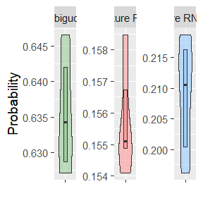

```r
library(ggplot2)
library(dplyr)
library(tidyr)

counts_data <- read.csv("D:/data/VeloRM_data/DART-seq/origin/bam_read_counts.csv",
                        header = TRUE,  # Assumes first row contains column names
                        stringsAsFactors = FALSE)  # Prevents automatic conversion to factors

# View the first few rows

counts_data_sum <- apply(counts_data,1,function(x) sum(as.numeric(x[2:4])))
isoform_prop <- as.numeric(counts_data[,2])/counts_data_sum
spliced_prop <- as.numeric(counts_data[,3])/counts_data_sum
pre_prop <- as.numeric(counts_data[,4])/counts_data_sum

df <- data.frame(
  `mature RNA` = spliced_prop,
  `pre RNA` = pre_prop,
  `ambiguous` = isoform_prop,
  check.names = FALSE
)
df_long <- pivot_longer(df, cols = everything(),
                        names_to = "Type",
                        values_to = "Probability")

box_plot <- ggplot(df_long, aes(x = "", y = Probability, fill = Type)) +
  geom_violin(alpha = 0.6, width = 0.7) +
  geom_boxplot(width = 0.2, alpha = 0.8,
               outlier.shape = NA,
               coef = 0) +
  facet_wrap(~Type, scales = "free_y", ncol = 3) +
  labs(
    title = NULL,
    x = NULL,
    y = "Probability"
  ) +
  # Use theme_gray() which is the default ggplot2 theme
  theme_gray(base_size = 14)  +
  scale_fill_manual(
    values = c("mature RNA" = "#FF9999",
               "pre RNA" = "#99CCFF",
               "ambiguous" = "#99CC99"),
    breaks = c("mature RNA", "pre RNA", "ambiguous")
  )+
  theme(
    legend.position = "none"
  )

box_plot
```

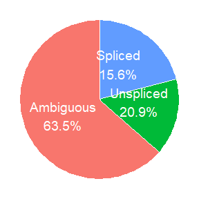

```r
# Create a data frame with the summed proportions
plot_data <- data.frame(
  category = c("Spliced", "Unspliced"),
  proportion = c(sum(counts_data[,3]), sum(counts_data[,4]))
)




plot_data <- data.frame(
  category = c("Spliced", "Unspliced", "Ambiguous"),
  proportion = c(sum(counts_data[,3]), sum(counts_data[,4]), sum(counts_data[,2]))
)

# percentage
plot_data$fraction <- plot_data$proportion / sum(plot_data$proportion)
plot_data$ypos <- cumsum(plot_data$fraction) - 0.5 * plot_data$fraction

# pie
pie_plot <- ggplot(plot_data, aes(x = "", y = fraction, fill = category)) +
  geom_bar(stat = "identity", width = 1, color = "white") +
  coord_polar("y", start = 0) +
  geom_text(aes(y = ypos, label = paste0(category, "\n", scales::percent(fraction, accuracy = 0.1))),
            color = "white", size = 5) +
  labs(title = NULL, x = NULL, y = NULL, fill = NULL) +
  theme_void(base_size = 14) +  # 清爽主题
  theme(legend.position = "none")

pie_plot
```

```r
DESeq2_res_spliced_overall <- readRDS("D:/data/VeloRM_data/DART-seq/pre_process/res_DESeq2_spliced.rds")
spliced_index <- which(DESeq2_res_spliced_overall@listData[["log2FoldChange"]]>1)

DESeq2_res_unspliced_overall <- readRDS("D:/data/VeloRM_data/DART-seq/pre_process/res_DESeq2_pre.rds")

unspliced_index <- which(DESeq2_res_unspliced_overall@listData[["log2FoldChange"]]>1)

spliced_index_l <- length(spliced_index)
unspliced_index_l <- length(unspliced_index)
intersect_l <- length(intersect(spliced_index,unspliced_index))


library(VennDiagram)
```

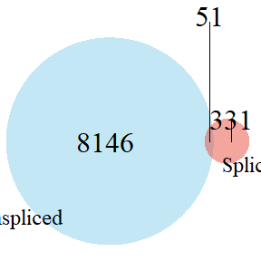

```r
grid.newpage()
venn <-draw.pairwise.venn(
  area1 = spliced_index_l,
  area2 = unspliced_index_l,
  cross.area = intersect_l,
  category = c("Spliced", "Unspliced"),
  fill = c("#E74C3C","skyblue"),
  alpha = 0.5,
  lty = "blank",
  cex = 2,
  cat.cex = 1.5
)
```

### DESeq2 results visulization

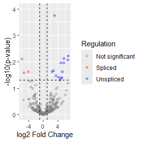

```r
### read the DESeq2 results

library(ggplot2)
library(dplyr)
library(tidyr)

res_DESeq2 <- readRDS("D:/data/VeloRM_data/DART-seq/pre_process/res_DESeq2.rds")


log2FC <-res_DESeq2@listData[["log2FoldChange"]]
pvals <- res_DESeq2@listData[["pvalue"]]

plot_data <- data.frame(log2FC = log2FC,
                        pvalue = pvals,
                        neg_log10_p = -log10(pvals))


volcano_plot_DESeq2 <- ggplot(plot_data, aes(x = log2FC, y = neg_log10_p)) +
  # Add light gray background for -1 < log2FC < 1 (non-significant FC region)
  annotate("rect", xmin = -1, xmax = 1, ymin = 0, ymax = 30,
           fill = "gray90", alpha = 0.3) +

  # Color points based on significance and log2FC:
  # - Red: log2FC > 1 & p < 0.05 (significantly up-regulated)
  # - Blue: log2FC < -1 & p < 0.05 (significantly down-regulated)
  # - Gray: Not significant or |log2FC| â‰¤ 1
  geom_point(aes(color = case_when(
    log2FC > 1 & pvalue < 0.05 ~ "Unspliced",
    log2FC < -1 & pvalue < 0.05 ~ "Spliced",
    TRUE ~ "Not significant"
  )), alpha = 0.3) +

  # Manual color scale (red, blue, gray)
  scale_color_manual(
    values = c(
      "Spliced" = "red",
      "Unspliced" = "blue",
      "Not significant" = "gray50"
    ),
    name = "Regulation"  # Legend title
  ) +

  # Add dashed lines for thresholds:
  # - Vertical: log2FC = Â±1
  # - Horizontal: p-value = 0.05 (-log10(0.05) â‰ˆ 1.3)
  geom_vline(xintercept = c(-1, 1), linetype = "dashed", color = "black") +
  geom_hline(yintercept = -log10(0.05), linetype = "dashed", color = "black") +

  # Axis labels and theme
  labs(
    x = "log2 Fold Change",
    y = "-log10(p-value)",
    title = NULL
  ) +
  theme_grey() +coord_cartesian(ylim=c(0,4))
volcano_plot_DESeq2
```

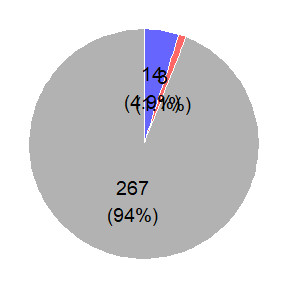

```r
n_unspliced <- length(which(log2FC >= 1 & pvals <= 0.05))
n_spliced <- length(which(log2FC <= -1 & pvals <= 0.05))
n_nonsig <- length(which((pvals > 0.05 | (log2FC > -1 & log2FC < 1))))

total <- n_unspliced + n_spliced + n_nonsig
Percentage <- round(c(n_unspliced, n_spliced, n_nonsig) / total * 100, 1)

df <- data.frame(
  Category = c("Unspliced", "Spliced", "Insignificant"),
  Count = c(n_unspliced, n_spliced, n_nonsig)
)



pie_chart_DESeq2 <- ggplot(df, aes(x = "", y = Count, fill = Category)) +
  geom_bar(stat = "identity", width = 1, color = "white",alpha=0.6) +
  coord_polar("y", start = 0) +
  geom_text(aes(label = paste0(Count, "\n(", Percentage, "%)")),
            position = position_stack(vjust = 0.5), size = 5) +
  scale_fill_manual(values = c("Unspliced" = "blue", "Spliced" = "red","Insignificant"="gray50")) +
  labs(
    title = NULL,
    x = NULL,
    y = NULL
  ) +
  theme_void() +
  theme(
    legend.position = "none"
  )

pie_chart_DESeq2
```

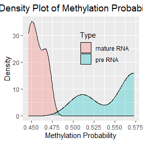

```r
# Load input data
test.list <- readRDS("D:/data/VeloRM_data/DART-seq/pre_process/test.list.rds")

# Extract different parts of the data
spliced.meth.test <- test.list[[1]]  # Methylated spliced data
spliced.unmeth.test <- test.list[[2]]  # Unmethylated spliced data
unspliced.meth.test <- test.list[[3]]  # Methylated unspliced data
unspliced.unmeth.test <- test.list[[4]]  # Unmethylated unspliced data
isoform.meth.test <- test.list[[5]]  # Methylated isoform data
isoform.unmeth.test <- test.list[[6]]  # Unmethylated isoform data





spliced.meth.sum.cell <- apply(spliced.meth.test,2,sum)#,apply(spliced.meth.control,2,sum))
spliced.unmeth.sum.cell <- apply(spliced.unmeth.test,2,sum)#,apply(spliced.unmeth.control,2,sum))
unspliced.meth.sum.cell <- apply(unspliced.meth.test,2,sum)#,apply(unspliced.meth.control,2,sum))
unspliced.unmeth.sum.cell <- apply(unspliced.unmeth.test,2,sum)#,apply(unspliced.unmeth.control,2,sum))
isoform.meth.sum.cell <- apply(isoform.meth.test,2,sum)#,apply(unspliced.meth.control,2,sum))
isoform.unmeth.sum.cell <- apply(isoform.unmeth.test,2,sum)#,apply(unspliced.unmeth.control,2,sum))

spliced.sum.cell <- spliced.meth.sum.cell + spliced.unmeth.sum.cell
unspliced.sum.cell <- unspliced.meth.sum.cell + unspliced.unmeth.sum.cell
isoform.sum.cell <- isoform.meth.sum.cell + isoform.unmeth.sum.cell

spliced.prob.cell <- spliced.sum.cell/(spliced.sum.cell+unspliced.sum.cell+isoform.sum.cell)
unspliced.prob.cell <- unspliced.sum.cell/(spliced.sum.cell+unspliced.sum.cell+isoform.sum.cell)
isoform.prob.cell <- isoform.sum.cell/(spliced.sum.cell+unspliced.sum.cell+isoform.sum.cell)


spliced.cell.prob <- spliced.meth.sum.cell/(spliced.unmeth.sum.cell+spliced.meth.sum.cell)
unspliced.cell.prob <- unspliced.meth.sum.cell/(unspliced.unmeth.sum.cell+unspliced.meth.sum.cell)

df <- data.frame(
  Probability = c(spliced.cell.prob, unspliced.cell.prob),
  Type = rep(c("mature RNA", "pre RNA"),
             c(length(spliced.cell.prob), length(unspliced.cell.prob)))
)

# Create the density plot
ggplot(df, aes(x = Probability, fill = Type)) +
  geom_density(alpha = 0.3) +
  labs(title = "Density Plot of Methylation Probabilities",
       x = "Methylation Probability",
       y = "Density") +
  theme_grey() +
  theme(
    plot.title = element_text(hjust = 0.5, size = 14),
    legend.position = c(0.7, 0.7),
    legend.background = element_blank())
```